# Scaling factors

First we are going to explore how the scaling factors are changing with elevation, latitude and time, and what is the impact on local production rates.

## Time-independent scaling

We are going to present the most widely used and simplest scaling scheme known as Lal-Stone and often abbreviated as **st**. The main equations are presented in the reference article by @stone2000air .

### Site characteristics

We first need to define some parameters concerning the site of interest :

- latitude `lat` in degrees
- altitude `z` in meters (can be a vector or a scalar)
- longitude `lon` in degrees, this is not used for *st* scaling (@stone2000air), just in case we want to compute atmospheric pressure according to ERA40 (@uppala2005era40).

```r
lat = 30 # latitude
lon = 30 # longitude
z = seq(0,3000,by=100) # vector from 0 to 3000 m by 100 m increments
```

Now we can compute the atmospheric pressure, with the function `atm_pressure` according to the two models available, and then plot for comparison. Here `z` is a vector to see the variations over a range of elevations.

To get information about the usage of the function used here (for example what are the different models) type `?atm_pressure` in the R console.

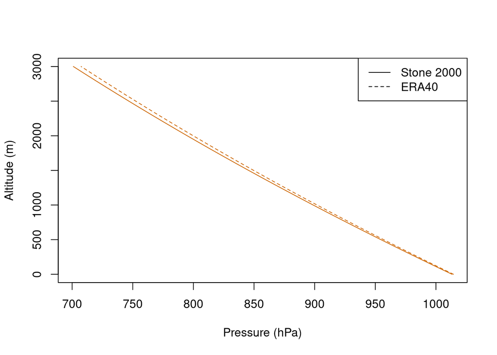

```r
P1 = atm_pressure(alt=z,model="stone2000")
P2 = atm_pressure(alt=z,lat=lat,lon=lon,model="era40")
plot(P1,z,type="l",xlab="Pressure (hPa)",ylab="Altitude (m)",col="darkorange3")
lines(P2,z,lty=2,col="darkorange3")
legend("topright",c("Stone 2000","ERA40"),lty=c(1,2))
```

> **TODO** Modify `lat` and `lon` to see the effects on the pressure computed with the ERA40 model

### Computation of scaling factors

We can now compute the scaling factors according to @stone2000air. Same as above, to get some information about the function (parameters definition) type `?st_scaling` in the R console.

```r
st = scaling_st(P1,lat) # here we use the pressure according to Stone 2000 model
print(st)
```

```
##    Nneutrons    Nmuons
## 1  0.8300224 0.8330000
## 2  0.9026631 0.8751951
## 3  0.9789258 0.9190924
## 4  1.0593995 0.9647381
## 5  1.1446610 1.0121787
## 6  1.2352759 1.0614606
## 7  1.3317993 1.1126307
## 8  1.4347771 1.1657357
## 9  1.5447466 1.2208226
## 10 1.6622372 1.2779383
## 11 1.7877718 1.3371297
## 12 1.9218669 1.3984436
## 13 2.0650339 1.4619266
## 14 2.2177794 1.5276253
```

[output cut: 17 more lines]

The result is stored in `st` as a dataframe with as many rows as there are elements in the input pressure vector (`P1`) and two columns named `Nneutrons` and `Nmuons`, for the spallogenic and muogenic contributions, respectively.

We can plot the evolution with elevation, which illustrates the major influence of altitude of the sampling site in controlling the local production rate.

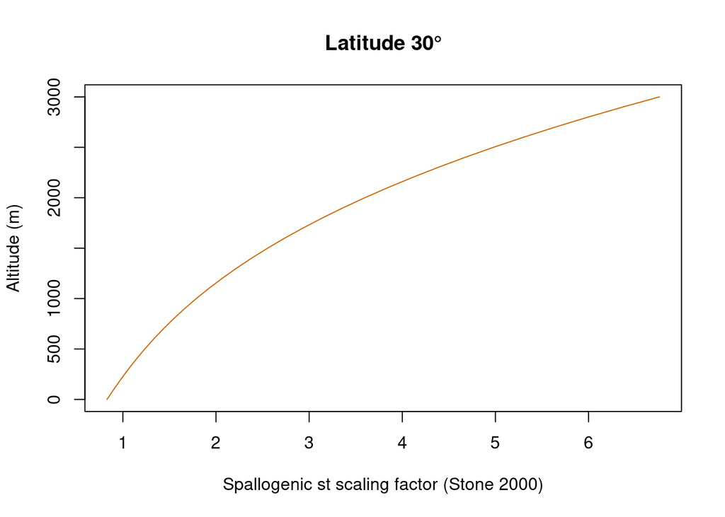

```r
plot(st$Nneutrons,z,type="l",
     xlab="Spallogenic st scaling factor (Stone 2000)",ylab="Altitude (m)",
     main=paste("Latitude ",lat,"°",sep=""),col="darkorange3")
```

> **TODO** Modify `lat` to see the effects on the scaling factor

### Global variations

In order to get a better idea of the variations with both latitude (from 0 to 90°) and elevation (from sea level to 3000 m) we can try the following plot.

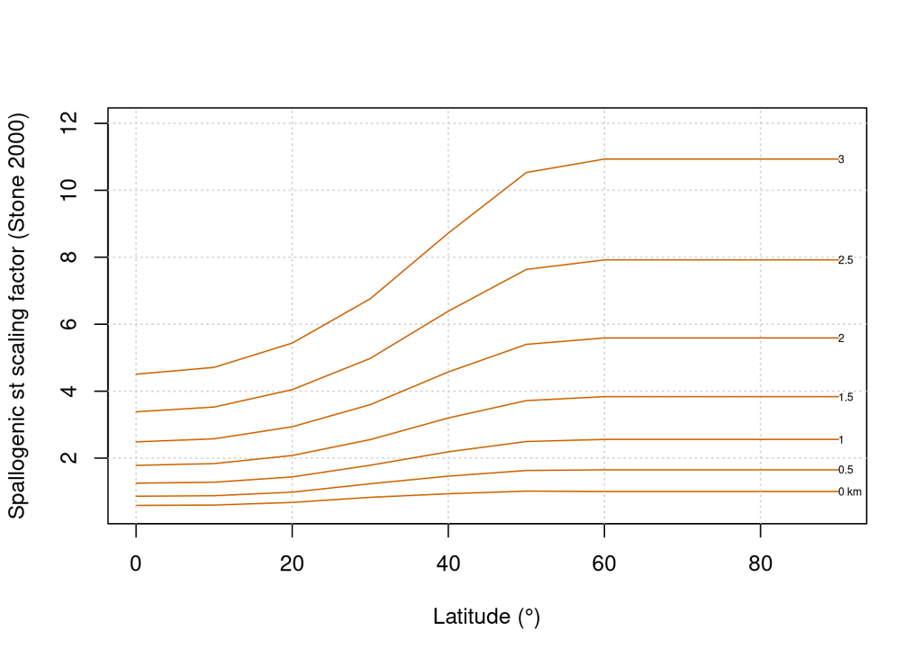

```r
P = atm_pressure(alt=0,model="stone2000") # compute pressure
lat = seq(0,90,by=1) # latitude vector
n = length(lat) # size of vector
st = scaling_st(P,lat) # compute scaling
plot(lat,st$Nneutrons,type="l",ylim=c(0.5,12),col="darkorange3",
     xlab="Latitude (°)",ylab="Spallogenic st scaling factor (Stone 2000)")
grid()
text(lat[n],st$Nneutrons[n],"0 km",cex=0.5,adj=0) # put label at the end of curve
for (z in seq(500,3000,by=500)){ # loop on elevations : same as above for a range of elevations
  P = atm_pressure(alt=z,model="stone2000")
  st = scaling_st(P,lat)
  lines(lat,st$Nneutrons,col="darkorange3")
  text(lat[n],st$Nneutrons[n],z/1000,cex=0.5,adj=0)
}
```

This dependence of the scaling factor on latitude is a direct consequence of the dipole structure of the Earth magnetic field, with a higher cosmic rays flux at high latitudes.

## Time-dependent scalings

### Definition of paleomagnetic variations

Time-dependent scaling factors allow to take into account the variations through time of the Earth magnetic field, which modulates the incoming cosmic ray flux. This is particularly important in exposure dating applications.

#### Virtual Dipole Moment

We need to first define a time series for the Virtual Dipole Moment (VDM) variation, using the `get_vdm` function.

Several paleomagnetic database can be used. The three options correspond to databases defined in [Crep](https://crep.otelo.univ-lorraine.fr). We plot the three of them on the same graph.

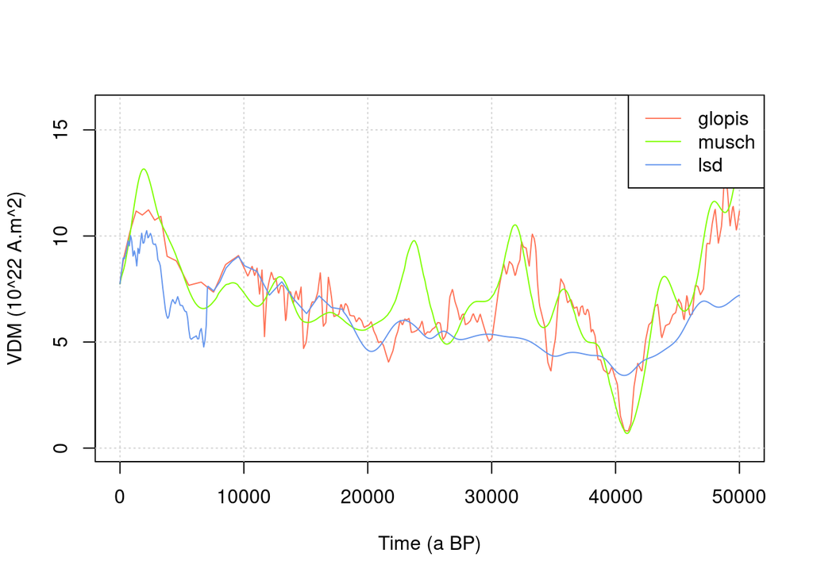

```r
time = seq(0,50e3,length.out = 1000) # time vector from 0 to 50 ka BP, with 1000 regularly spaced elements
#
plot(NA,xlim=range(time),ylim=c(0,16),xlab="Time (a BP)",ylab="VDM (10^22 A.m^2)")
grid()
# - Glopis
col1="coral1"
vdm1=get_vdm(time,model="glopis")
lines(time,vdm1/1e22,col=col1)
# 2 - Musch
col2 = "chartreuse"
vdm2=get_vdm(time,model="musch")
lines(time,vdm2/1e22,col=col2)
# 3 - lsd
col3 = "cornflowerblue"
vdm3=get_vdm(time,model="lsd")
lines(time,vdm3/1e22,col=col3)
legend("topright",c("glopis","musch","lsd"),col=c(col1,col2,col3),lty=1)
```

#### Cutoff Rigidity

Now we need to convert that into cutoff rigidity using `vdm2rc` function. Such can be done using the following expression (@martin2017crep):
$$R_c = 14.3 \frac{M}{M_0}\cos^4 \lambda,$$
where $M$ is the moment of the Earth dipole field, $M_0$ the 2010 reference value for $M$ and $\lambda$ the latitude. This corresponds to the default `model=elsasser54` in the `vdm2rc` function arguments. A more complex formula proposed by @lifton2014scaling can be used with `model=lifton14`.

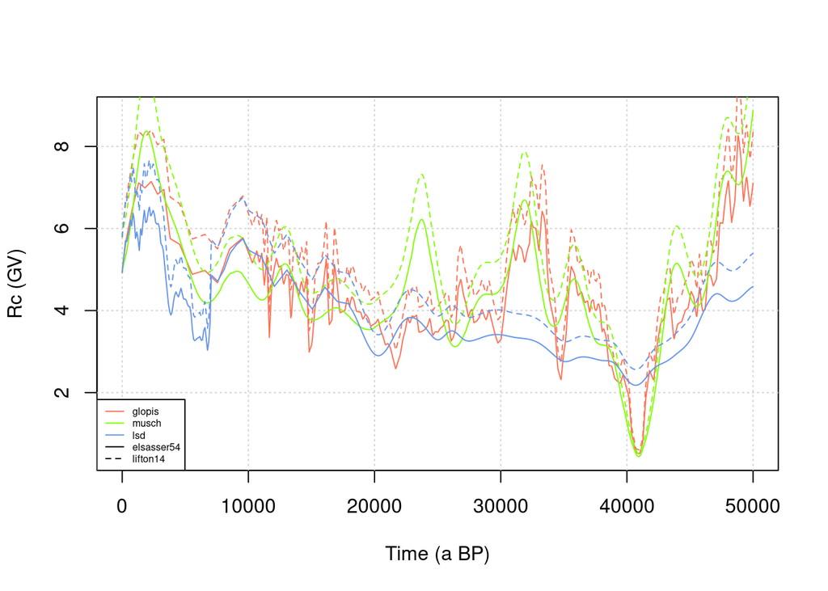

```r
lat = 40
rc1a = vdm2rc(vdm1,lat)
rc1b = vdm2rc(vdm1,lat,model="lifton14")
rc2a = vdm2rc(vdm2,lat)
rc2b = vdm2rc(vdm2,lat,model="lifton14")
rc3a = vdm2rc(vdm3,lat)
rc3b = vdm2rc(vdm3,lat,model="lifton14")
#
plot(NA,xlim=range(time),ylim=range(rc1a,rc2a,na.omit(rc3a)),xlab="Time (a BP)",ylab="Rc (GV)")
grid()
lines(time,rc1a,col=col1)
lines(time,rc1b,col=col1,lty=2)
lines(time,rc2a,col=col2)
lines(time,rc2b,col=col2,lty=2)
lines(time,rc3a,col=col3)
lines(time,rc3b,col=col3,lty=2)
legend("bottomleft",c("glopis","musch","lsd","elsasser54","lifton14"),col=c(col1,col2,col3,"black","black"),lty=c(1,1,1,1,2),cex=0.5)
```

> **TODO** change the latitude `lat` and observe the influence on $R_c$

### Lal/Stone modified scaling (*lm*)

Once we have a $R_c$ time series we can compute the *lm* scaling factors using the `scaling_lm` function. For that we will only use one elevation (*z=0*), so we recompute the atmospheric pressure. We plot the corresponding time series, as well as the value of *st* scaling factor for reference.

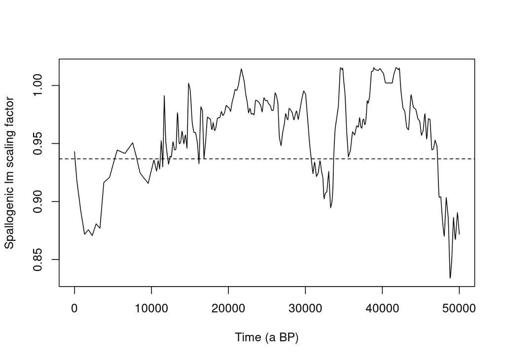

```r
P = atm_pressure(alt=0,model="stone2000")
lm = scaling_lm(P,rc1a)
plot(time,lm,type="l",xlab="Time (a BP)",ylab="Spallogenic lm scaling factor")
abline(h=scaling_st(P,lat)$Nneutrons,lty=2)
```

> **TODO** Explore the variations of the scaling factor by using various values for elevation `alt`, and different $R_c$ time-series. Look for the differences with the time-independant `st` scaling